# Principal Components Analysis

Albert Y. Kim

10/17/2017

## 1. Data

The data consists of SAT scores for the 50 states in 1994-1995:

```r
library(tidyverse)
SAT <- read_csv("http://people.reed.edu/~jones/141/sat.csv") %>%
  select(State, salary, expend)
head(SAT)
```

| State | salary | expend |
| --- | --- | --- |
| Alabama | 31.1 | 4.41 |
| Alaska | 48.0 | 8.96 |
| Arizona | 32.2 | 4.78 |
| Arkansas | 28.9 | 4.46 |
| California | 41.1 | 4.99 |
| Colorado | 34.6 | 5.44 |

```r
X <- SAT %>%
  select(salary, expend)
```

Let `X` be of dimension $n \times p = 50 \times 2$, where our observations $\vec{X} = (X_1, X_2)$ are

- $X_1$ `salary`: estimated average annual salary of teachers in public elementary and secondary schools (in $1000 of USD)
- $X_2$ `expend`: expenditure per pupil in average daily attendance in public elementary and secondary schools (in $1000 of USD)

The two variables `salary` and `expend` are highly correlated ($\rho=$ 0.87). You can think of them as being redundant; once you know one variable, the other variable doesn’t provide you with all that more information. This is very apparent in the plot below (with the regression line being dashed):

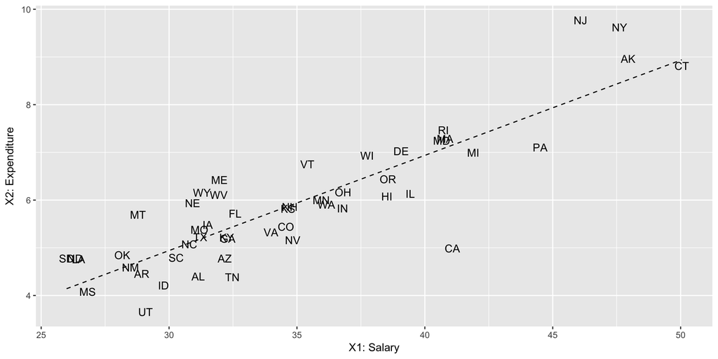

Note such *collinear* variables are a problem in a regression setting, because they “steal” each other’s effect, so it becomes difficult to isolate the effect of one vs the other. In other words, you have very unstable estimates of their $\beta$ coefficients/slopes.

## 2. Recentering Covariates

We first recenter both `salary` and `expenditure` to each have mean 0 by subtracting their sample means $(\overline{x}_1, \overline{x}_2) = ( 34.829, 5.905)$ respectively:

```r
X_recenter <- X %>%
  mutate(
    salary = salary - mean(salary),
    expend = expend - mean(expend)
  )
```

We plot the two variables recentered at $(0, 0)$.

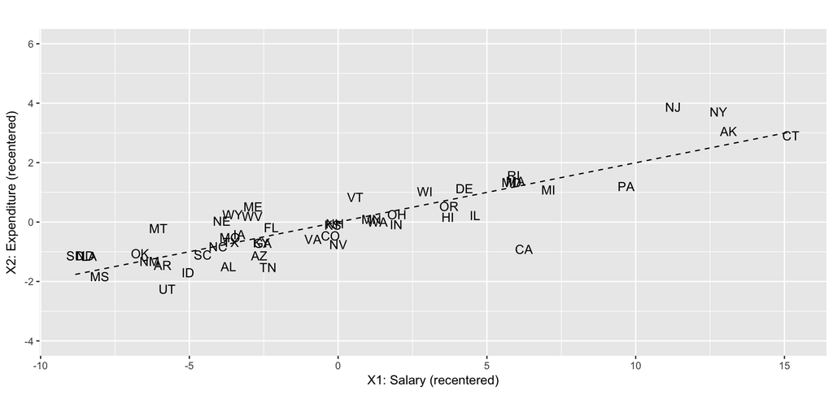

We compute the *sample/empirical* $2 \times 2$ covariance matrix for both `X` and `X_recenter` (Note for students who have taken MATH310 Probability: they are identical since variances/covariances are invariant to linear transformations):

```r
cov(X) %>% round(3)
```

```
##        salary expend
## salary  35.30   7.04
## expend   7.04   1.86
```

```r
cov(X_recenter) %>% round(3)
```

```
##        salary expend
## salary  35.30   7.04
## expend   7.04   1.86
```

## 3. Principal Components

Using R’s built-in linear algebra functionlity, we

- Compute the first and second principal components. Linear algebra fact: they are the first and second *eigenvectors* $\vec{\gamma}_1$ & $\vec{\gamma}_2$ of the covariance matrix.
- Plot them in red and blue respectively.

```r
eigen <- cov(X_recenter) %>% eigen()
eigen_vals <- eigen$values
Gamma <- eigen$vectors
```

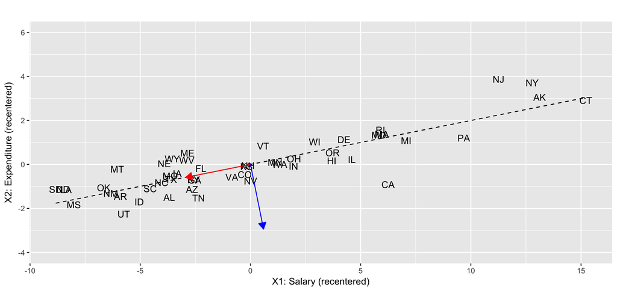

Notice:

- How the first principal component (in red) is in fact the regression line. Of all the components (arrows) you can draw on this plot, this one *captures/explains the most variability in $(X_1, X_2)$*. Intuitively speaking, most of the action of the 50 points is along the red arrow.
- How the second principal component (in blue) *captures/explains the variability in $(X_1, X_2)$ leftover after the first principal component*. Intuitively speaking, there is less action along the blue arrow.
- The two principal components are perpendicular to each other. Linear algebra fact: not only do they form a *spanning set* AKA are *linearly independent*, they form an *orthogonal basis*.

## 4. Transformation to Principal Component Space

For any point $\vec{X} = (X_1, X_2)$, we can transform it (AKA convert it) to principal components space $\vec{Y} = (Y_1, Y_2)$ by applying the matrix multiplication:

$$(Y_1, Y_2) = (X_1 - \overline{x}_1, X_2 - \overline{x}_2) \left(
\vec{\gamma}_1, \vec{\gamma}_2
\right)$$

```r
# Transform n x p matrix of observations to new principal components space:
Y <- as.matrix(X_recenter) %*% Gamma %>%
  as_data_frame() %>%
  rename(Y1 = V1, Y2 = V2)
```

In other words the first 5 rows of `X`

| salary | expend |
| --- | --- |
| 31.1 | 4.41 |
| 48.0 | 8.96 |
| 32.2 | 4.78 |
| 28.9 | 4.46 |
| 41.1 | 4.99 |

become

| Y1 | Y2 |
| --- | --- |
| 3.91 | 0.741 |
| -13.47 | -0.399 |
| 2.83 | 0.579 |
| 6.07 | 0.250 |
| -5.95 | 2.133 |

Let’s visualize the 50 points in original space $(X_1, X_2)$ with how they look in principal components space $(Y_1, Y_2)$:

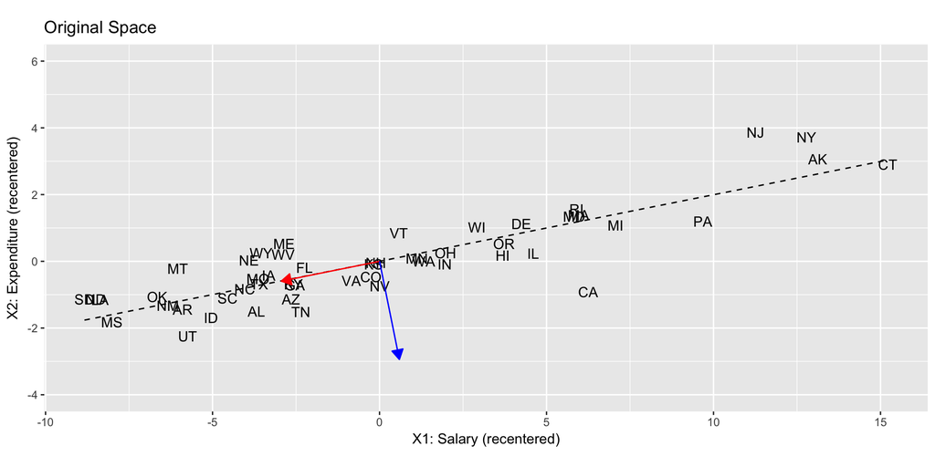

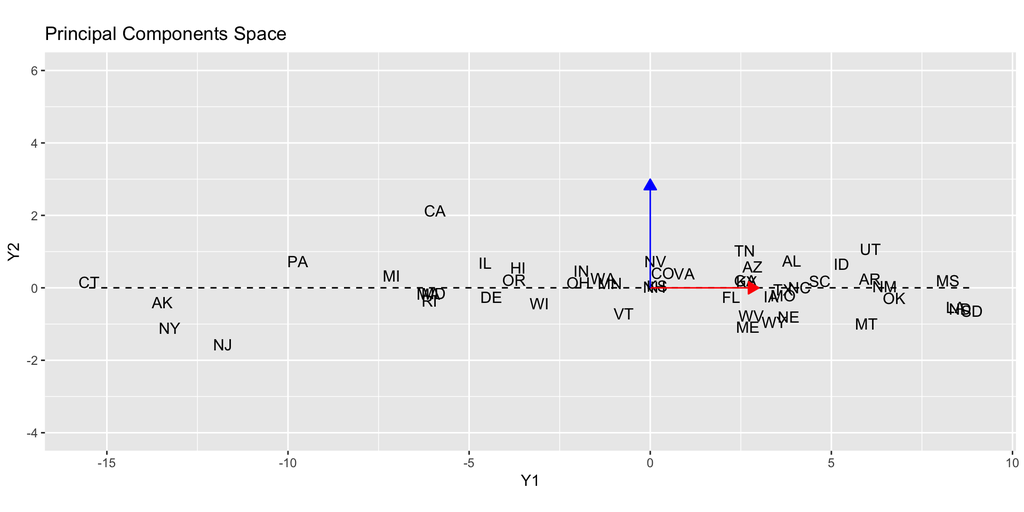

## 5. Who cares?

Let’s compare the sample covariance matrices of the 50 points in both spaces:

```r
cov(X) %>% round(3)
```

```
##        salary expend
## salary  35.30   7.04
## expend   7.04   1.86
```

```r
cov(Y) %>% round(3)
```

```
##      Y1    Y2
## Y1 36.7 0.000
## Y2  0.0 0.435
```

Notice:

- The sum of the variances of the $\vec{X}$ equals the sum of the variances of the $\vec{Y}$ (the sum along the diagonals = 37.156). *In other words, the total variability of the 50 points is the same in both spaces*.
- The off-diagonals in principal component space, however, are all 0. In other words, $Y_1$ and $Y_2$ are uncorrelated.
- Linear algebra fact: the diagonal of `cov(Y)` are in fact the *eigenvalues* corresponding to the above mentioned eigenvectors, and are guaranteed to be in order of largest to smallest.

Let’s look at the variances of $Y_1$ and $Y_2$ and their cummulative proportion:

```r
var_Y <- cov(Y) %>% diag()
var_Y
```

```
##     Y1     Y2
## 36.721  0.435
```

```r
cumsum(var_Y)/sum(var_Y)
```

```
##    Y1    Y2
## 0.988 1.000
```

**Moral of the Story**: We observe that 98.8% of the variability of the salary and expenditure variables is explained by the first principal component! So one would be inclined to use the single variable $Y_1$ and call it “school funding.”

**Occam’s Razor**: If 98.8% of the total variability in salary and expenditure can be explained with this single variable “school funding”, why not use only this single variable? Remember: all other things being equal, simpler models are better.

**Caveat**: Unfortuately the interpretation of $Y_1$ is hard to make sense of. They do seem to represent $1000 USD, but money corresponding to what exactly? This is one of the downsides of PCA, a loss of interpretability.

**Note**: This method generalizes to any dimensional space of predictors $\vec{X}$ for $p\geq2$. We don’t do that here because its hard to visualize once $p$ gets large.